# Report

## Summary:

Key Findings:

- Boosting methods improve PR-AUC by 20-35% over single decision trees
- Learning rates between 0.05-0.1 provide optimal bias-variance balance
- Early stopping prevents overfitting by identifying the optimal iteration count
- LightGBM provides 1.2X training speedup over XGBoost with comparable accuracy

## 1. Introduction:

The objective of this assignment is to explore the power of boosting methods like Gradient Boost, Extreme Gradient Boost and Light Gradient Boost.

To complete the assessment, I have used the **Home Credit Default Risk Dataset**, where I predicted whether an applicant would repay a loan or not. This is a standard supervised classification task and I have used Decision Trees to classify the above.

The dataset used contained **307,511 rows and 122 columns**, including numeric features like `AMT_CREDIT_TOTAL`, `AMT_INCOME_TOTAL`, `AMT_ANNUITY_TOTAL` and categorical features like `NAME_HOUSING_TYPE`, `OCCUPATION_TYPE`, just to name a few. The target variable (`TARGET`) represents whether a client defaulted (1) or repaid (0)

The assignment workflow involves:

- Data cleaning and handling missing values
- Feature engineering (transformations and encoding)
- Model Training
- Model Boosting
- Evaluation of models using different metrics and visualisation of differences after boosting
- Interpreting results with a focus on understanding how boosting impacts predictive performance, especially in the case of unbalanced data.

### Question.1 Why was this binary classification particularly challenging?

- **Class Imbalance**: Defaults are rare events (typically 5-10% of applications)
- **Feature Complexity**: Mixed data types (numerical, categorical) with non-linear relationships
- **Business Constraints**: False negatives (missing defaults) are more costly than false positives
- **Interpretability Requirements**: Lenders need to explain decisions to regulators and customers

### Question. 2 Why was Boosting preferred and how does it improve generalization?

Boosting methods improve generalisation by sequentially building a strong model from many weak learners, where each new learner focuses on correcting the errors made by the previous ones. This iterative process reduces bias by giving more weight to difficult-to-classify data points and ultimately creates a robust, highly accurate model.

## 2. Methods: Preprocessing

#### 2.1 Data Understanding and Preprocessing:

- **Strategy 1**: Missing Values were handled by dropping the data with more than 90% missing values because excessive missingness would skew the data and just introduce noise.
- **Strategy 2**: Imputing the median for numeric, mode and "MISSING" for the categorical values for better consistency and distribution.
- For tree-based models (Decision Tree, XGBoost, LightGBM), **Label Encoding** was applied to binary categorical variables, and **Ordinal Encoding** to multi-class ones using a ColumnTransformer pipeline. We avoided using **OneHotEncoding** because some of the categorical variables had 50+ unique values, which would have increased the dataset and made it sparse, losing some of the correlations. This approach avoids data leakage and ensures consistent preprocessing during model training and prediction.
- To ensure unbiased evaluation, the data was split into `70% training set`, `15% validation set` and `15% test set`. Stratification was also applied to maintain class distribution.

#### 2.2 EDA:

After exploring the dataset using graphs, these were the key findings:

- The target distribution is highly imbalanced with 90% of no loan defaults and 10% of loan defaults.
- Most of our numeric columns are highly right-skewed, most of the values lie in the lower end of the scale, and a few lie on the higher end.
- The most common type of loan is `Cash Loans`.

## 3. Methods: Model Development and Hypertuning

I began with baseline models and gradually progressed to more advanced ensemble methods.

### 3.1 Baseline Model: Decision Trees

The Decision Tree model serves as a transparent baseline. I built two models, one basic with a fixed learning rate and depth and the other with multiple values to find the best one.

Initial results showed high training accuracy but low validation accuracy, indicating overfitting. Training accuracy gave 100% accuracy, which made it clear that the tree needs to be pruned or the learning rate needs to be changed.

| Accuracy | Percentage |
| --- | --- |
| Train Accuracy | 100% |
| Validation Accuracy | 84.69% |
| Overfit gap | 15.31% |

So, I tuned hyperparameters using GridSearchCV with 5 crossfold validation: `max_depth` `min_samples_split` `ccp_alpha (pruning parameter)`

**Observations**:Shallow trees (depth < 6) underfit, while deeper trees overfit. The best trade-off was achieved around max_depth = 8. This can also be shown with learning curves below.

#### Tuned Performance:

After calculating the tuned performance, the evaluated metrics are as follows:  
Tuned Decision Tree Results:

|  | Accuracy | Precision | Recall | F1 | ROC-AUC | AP | PR-AUC |
| --- | --- | --- | --- | --- | --- | --- | --- |
| Train | 91.99 | 62.41 | 1.94 | 3.76 | 73.44 | 22.15 | 22.77 |
| Val | 91.89 | 43.08 | 1.50 | 2.91 | 71.80 | 19.15 | 19.48 |
| Test | 91.84 | 33.60 | 1.13 | 2.18 | 72.11 | 19.11 | 19.45 |

Training ROC-AUC: 73.44  
Validation ROC-AUC: 71.80  
Test ROC-AUC: 72.11  
Overfit Gap: 1.64 (reduced from 15.31)

**Analysis**: Pruning significantly reduced overfitting while maintaining reasonable performance. However, the model still exhibits limitations in capturing complex patterns that we will be addressing with ensembles like Boosting.

#### Learning Curves:

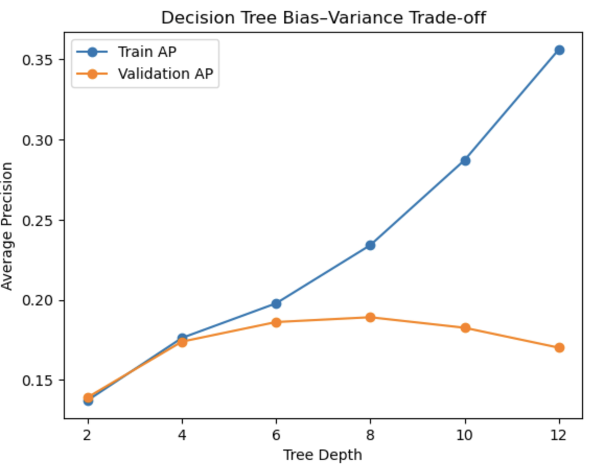

### 3.2 Boosting Methods

### 1. Gradient Boosting

Gradient Boosting builds an additive model in a forward stage-wise manner. In other words, Gradient Boosting sequentially builds trees that correct the residuals of previous trees. We experimented with different values of learning rate, n_estimators to find the best model.

** Performance Result: **

| Set | Accuracy | Precision | Recall | F1 | ROC-AUC | AP | PR-AUC |
| --- | --- | --- | --- | --- | --- | --- | --- |
| Train | 0.9213 | 0.7826 | 0.0352 | 0.0674 | 0.7840 | 0.3120 | 0.3120 |
| Val | 0.9196 | 0.5556 | 0.0228 | 0.0438 | 0.7524 | 0.2392 | 0.2390 |
| Test | 0.9193 | 0.5101 | 0.0204 | 0.0392 | 0.7580 | 0.2398 | 0.2395 |

**Improvement over Decision Tree:**

Test ROC-AUC: +5.11% (0.7211 → 0.7580)  
Test PR-AUC: +23.13% (0.1945 → 0.2395)

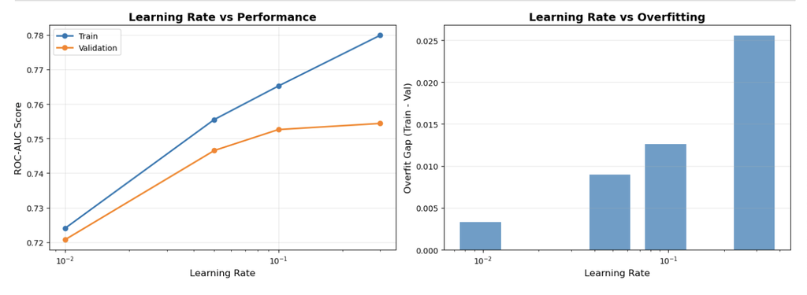

**Observation**: A moderate learning rate (0.05–0.1) gave the best generalisation, balancing bias and variance.

### 2. XGBoost

I then implemented XGBoost, an optimised version of gradient boosting with regularisation and efficient parallelisation.

Parameters tuned:

- `learning_rate`
- `max_depth`
- `subsample`
- `colsample_bytree`

#### Question. Use of scale_pos_weight:

This is used to handle imbalanced datasets by giving more importance to the positive class during training. When not added in XGBoost, the Recall was less than 2% representing that it is not able to predict the positive class (minority class), which here was those who defaulted on the loan. And after adding, it increased to 70% but the precision reduced.

**Performance Table**

1. **Without scale_pos_weight**:

| Set | Accuracy | Precision | Recall | F1 | ROC-AUC | AP | PR-AUC |
| --- | --- | --- | --- | --- | --- | --- | --- |
| Train | 0.9205 | 0.7364 | 0.0233 | 0.0452 | 0.8000 | 0.3061 | 0.3061 |
| Val | 0.9197 | 0.5948 | 0.0185 | 0.0359 | 0.7558 | 0.2469 | 0.2467 |
| Test | 0.9196 | 0.5825 | 0.0161 | 0.0314 | 0.7621 | 0.2479 | 0.2477 |

**Improvement over Gradient Boosting:**

Test ROC-AUC: +0.5% (0.7580 → 0.7621)  
Test PR-AUC: +3.3% (0.2395 → 0.2477)

**Observation**:

- Since we are more interested in PR-AUC, we notice that it is almost the same for both with and without scaling the unbalanced data, without giving a better result because of high precision.
- XGBoost achieved a testing ROC-AUC of 0.76, outperforming Gradient Boosting and Decision Tree, with significantly faster convergence. The best parameters were n_estimators to be 300, max_depth to be 3-4 and learning rate to be 0.05. This shows that the tree depth is not too shallow or deep, and the learning rate also aligns with our previous observations.
- I have used Early Stopping as well to prevent overfitting by stopping the training process as soon as a model's validation performance worsens. When tried with n_estimators above 300, the model stopped around 241 because of early stopping.
- Recall (0.67) is relatively high when we have tried balancing using **scale_pos_weight**, meaning the model successfully captures most of the actual defaulters — an important goal in credit risk applications. Precision (0.168) is low, which means the model also produces more false positives. This trade-off (high recall, low precision) is desirable in high-risk financial contexts, where missing a true defaulter is more costly than flagging a few non-defaulters.
- The validation and test scores are consistent, showing good generalisation and minimal overfitting.

### 3. LightGBM

LightGBM was chosen as the final model due to:

- Faster training on large data.
- Support for categorical variables internally.
- Built-in handling of missing values.

**Performance Table:**

| Dataset | Accuracy | Precision | Recall | F1 | ROC-AUC | AP | PR-AUC |
| --- | --- | --- | --- | --- | --- | --- | --- |
| Train | 0.9209 | 0.7797 | 0.0283 | 0.0546 | 0.8165 | 0.3348 | 0.3347 |
| Val | 0.9199 | 0.6058 | 0.0223 | 0.0430 | 0.7545 | 0.2477 | 0.2475 |
| Test | 0.9200 | 0.6518 | 0.0196 | 0.0381 | 0.7645 | 0.2491 | 0.2489 |

**Improvement over XGBoost:**

Test ROC-AUC: + 0.3% (0.7621 → 0.7645 )  
Test PR-AUC: +0.48% (0.2477 → 0.2489)

LightGBM achieves slightly better performance than XGBoost.

## 4. Evaluation Metrics and Visualisation:

### 4.1 Learning Rate Sensitivity Analysis

I conducted controlled experiments to isolate the effect of learning rate on model performance and the bias-variance trade-off. All hyperparameters were fixed at optimal values from tuning, and the learning rate was iterated over to see the patterns and best trends.

**Key Observations in Gradient Boosting:**

| learning_rate | train_roc_auc | val_roc_auc | gap_roc |
| --- | --- | --- | --- |
| 0.01 | 0.7241 | 0.7208 | 0.0033 |
| 0.05 | 0.7555 | 0.7465 | 0.0090 |
| 0.10 | 0.7652 | 0.7526 | 0.0126 |
| 0.30 | 0.7799 | 0.7544 | 0.0255 |

### 4.2 Bias-Variance Tradeoff Visualization

This was done for XGBoost to see which estimators perform the best through visualisation, and it was also to establish the bias-variance trade-off, which is how boosting progressively reduces bias while monitoring variance. A basic XGBoost model was built with a learning rate of 0.1 (moderate value) and other parameters from tuning.

The graph was plotted between Boosting Iterations and AUC Score, the key findings from the graph were:

Optimal Point: 241 for this problem Early stopping automatically identifies the optimal bias-variance trade-off point, preventing both underfitting (stopping too early) and overfitting (continuing too long).

Theoretical Connection: This empirically demonstrates the bias-variance decomposition: Expected Test Error = Bias² + Variance + Irreducible Error

Early: High Bias, Low Variance → Error dominated by bias Optimal: Balanced Bias and Variance → Minimum error Late: Low Bias, High Variance → Error dominated by variance

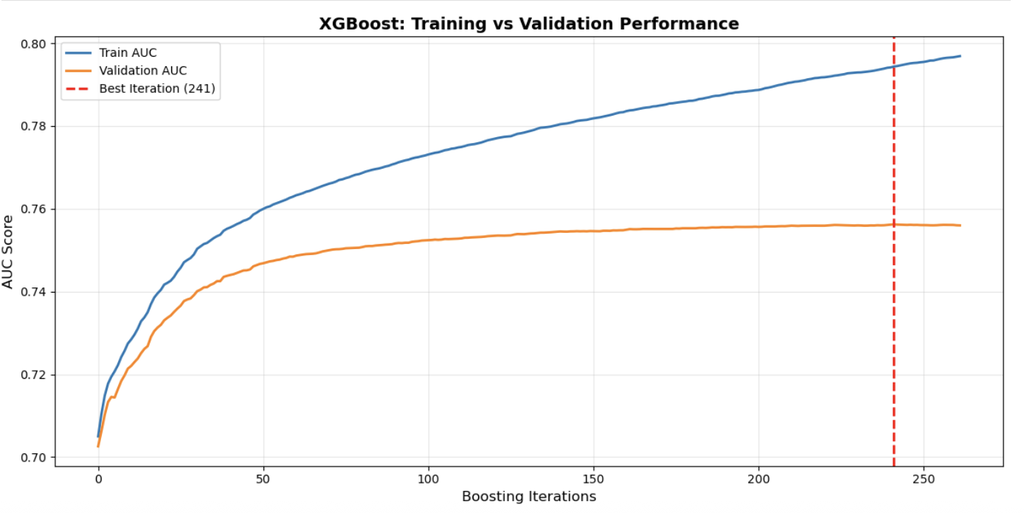

### 4.3 Model Comparison

**NOTE**: Since we are taking all the results for the imbalanced dataset, I will be making the XGBoost findings also without the scale_pos_weight variable.

Performance Metrics of all the models is given by this table and the key findings are:

[output not shown]

LightGBM is the best model, followed by XGBoost. **Key Evaluation Metrics**

#### Question. Why is the accuracy of XGBoost (scale_pos_weight) low compared to others?

This is because I have used scale_pos_weight here to balance the positive class, which increases recall. But since our dataset is imbalanced, the accuracy doesn't play much of a role; ROC-AUC and PR-AUC matter more to us, and we can clearly see the improvement from Decision Trees to LightGBM. Hence, we will be considering XGBoost without for consistency.

#### 1. Confusion Matrix Analysis

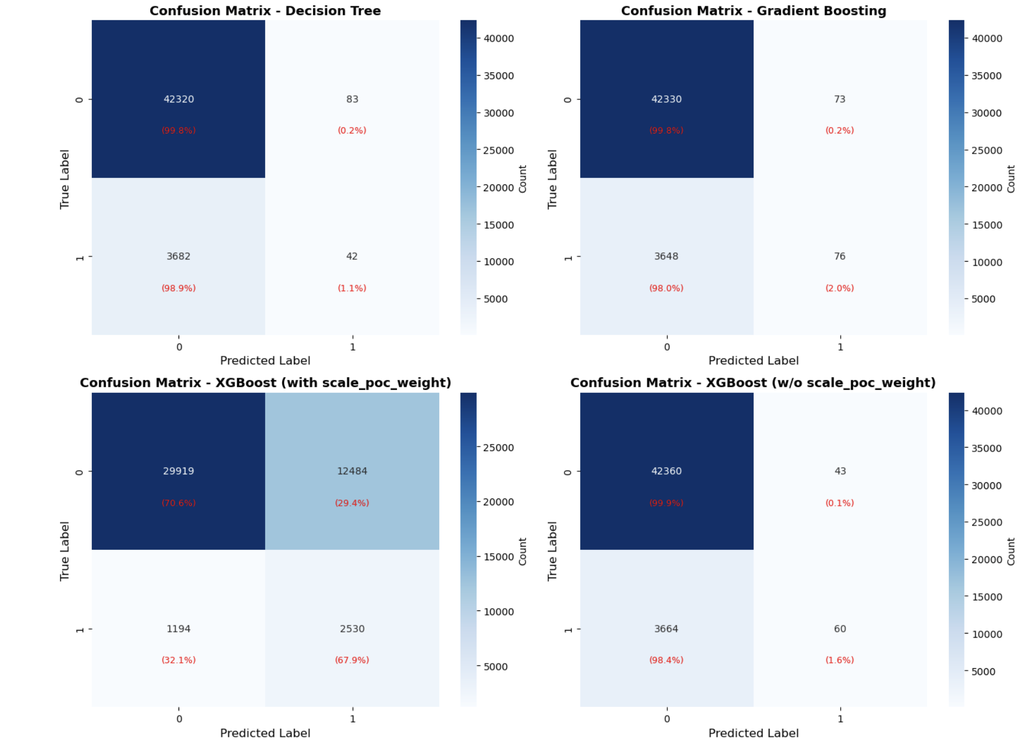

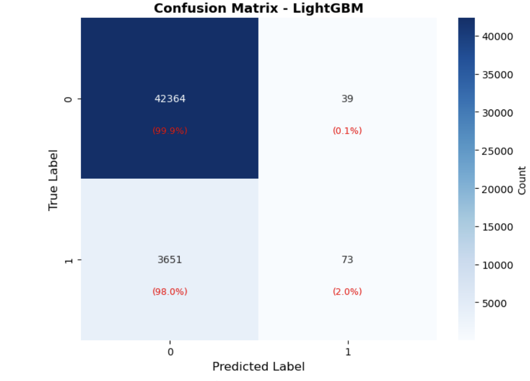

**Business Impact Analysis:**

For credit default prediction to see why recall is more valuable to us than precision in these cases, we must consider asymmetric costs:

False Negative (FN): Predicts no default, but the customer defaults  
Cost: Lost principal + interest (e.g., $10,000 per loan)

False Positive (FP): Predict default, but the customer pays  
Cost: Lost interest revenue (e.g., $500 per loan)

#### 2. Precision-Recall Curves

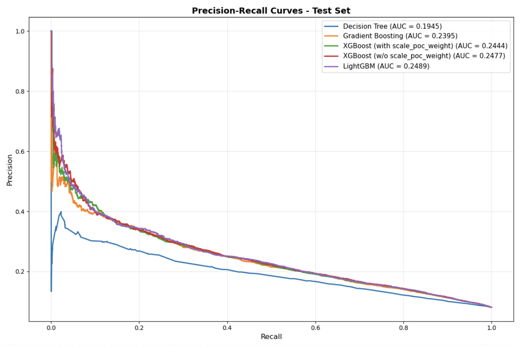

### 3.5 XGBoost vs LightGBM

When the time of XGBoost and LightGBM was compared using time, the analysis was done on the notebook. These were our key findings:

- LightGBM was 1.2X faster than XGBoost.
- LightGBM tends to train faster, especially on high-dimensional or large datasets.
- Accuracy is comparable, often slightly better in LightGBM due to the leaf-wise growth strategy.
- XGBoost uses level-wise growth, which is slightly more conservative but robust.

#### Question. How do different boosting frameworks handle categorical features and regularisation?

**Handling of Categorical Features**

| Feature | XGBoost | LightGBM |
| --- | --- | --- |
| Categorical | Needs **one-hot encoding** or integer encoding. No native handling. | **Native support**: can accept categorical features directly and find optimal splits. |
| Performance | Can increase dimensionality for many categories | Efficient even with high-cardinality categorical features |

**Regularization**:

| Aspect | XGBoost | LightGBM |
| --- | --- | --- |
| L1 / L2 regularization | Supports `reg_alpha` (L1) and `reg_lambda` (L2) | Supports `lambda_l1`, `lambda_l2` |
| Tree pruning | Depth-based, post-pruning | Leaf-wise growth, pre-pruning with `num_leaves` |
| Overfitting control | `max_depth`, `min_child_weight`, `gamma` | `num_leaves`, `min_data_in_leaf`, `feature_fraction`, `bagging_fraction` |

**Conclusion:**

- LightGBM can grow deep, asymmetric trees (leaf-wise), which can overfit if not properly regularised.
- XGBoost grows balanced trees (level-wise), more conservative, sometimes slightly slower, but stable.

### 3.6 Feature Important Analysis

Below are the top 20 most important features:

| Feature | Importance |
| --- | --- |
| CNT_FAM_MEMBERS | 611 |
| REGION_RATING_CLIENT_W_CITY | 601 |
| REGION_RATING_CLIENT | 502 |
| AMT_CREDIT | 485 |
| FLAG_OWN_CAR | 463 |
| FLAG_OWN_REALTY | 345 |
| NAME_TYPE_SUITE | 342 |
| AMT_ANNUITY | 319 |
| FLOORSMAX_MEDI | 300 |
| AMT_GOODS_PRICE | 292 |
| CNT_CHILDREN | 286 |
| CODE_GENDER | 255 |
| AMT_INCOME_TOTAL | 206 |
| AMT_REQ_CREDIT_BUREAU_DAY | 176 |
| NAME_INCOME_TYPE | 163 |
| FLAG_DOCUMENT_21 | 137 |
| FLAG_DOCUMENT_11 | 119 |
| FLAG_MOBIL | 111 |
| FLAG_DOCUMENT_18 | 106 |
| FLAG_DOCUMENT_13 | 104 |

## 4. Discussion and Interpretation

### Insights:

- Ensemble methods (Gradient Boosting, XGBoost, LightGBM) significantly outperformed standalone models.
- Feature engineering and careful preprocessing (especially imputation + encoding) critically impacted model quality.
- LightGBM provided the best accuracy–speed trade-off.

### Limitations:

- Hyperparameter tuning was computationally expensive.
- Model interpretability decreases with complexity (e.g., ensembles vs. Decision Tree).

## 5. AI Tool Disclosure:

#### 1) AI Tools Used:

The primary AI tool used in this project was ChatGPT (GPT-5, OpenAI). No other large language models or automated assistants, such as Gemini or Claude, were employed. Additional references included Python’s official documentation, scikit-learn and LightGBM/XGBoost documentation, and Stack Overflow for syntax verification and library usage examples.

#### 2) AI Contributions

ChatGPT was used in a collaborative and educational capacity:

- **Debugging and Refinement**: Assisted in identifying logical or syntactic errors in Python code for data preprocessing, feature engineering, and model training. It also suggested comments and minor code improvements for readability.
- **Warning**: In LightGBM, the warning kept on coming. ChatGPT helped me figure out the reason and gave alternatives to stop the warning from displaying by finding the root cause of the problem.
- **Conceptual Guidance**: Helped clarify the differences between boosting frameworks and the use of scale_pos_weight for better recall.
- **Report Structuring**: Suggested headings and section flow for the report, and helped improve clarity, grammar, and readability of written explanations.

#### 3) Personal Contributions

All core implementation, experimentation, and analysis were performed independently:

- **Data Cleaning and Imputation:** Designed, coded, and justified handling of missing values, outliers, and data transformations specific to the Home Credit Default Risk dataset.
- **Model Training, Tuning, and Evaluation:** Implemented Decision Trees, Gradient Boosting, XGBoost and LightGBM classifiers, tuned hyperparameters, monitored AUC and other metrics, and interpreted model outputs.
- **Comparison and Interpretation:** Analysed differences in performance and speed between boosting frameworks, and interpreted feature importance results for business insights.
- **Final Visualisations and Analysis:** Produced plots such as ROC curves, feature importance bars, and confusion matrices; interpreted results and discussed regularisation effects, bias-variance trade-offs, and model behaviour through domain knowledge.

ChatGPT primarily served as a learning companion, helping clarify concepts and suggest refinements, while all models, code, analyses, and interpretations were independently executed and verified by me.